# Muss_PCA_GLM_DMX_Benthic

Rachael Blake

September 16, 2016

# Regional Scale Analyses

#### H1: Mussel recruitment (via abundance) is associated with strong wind stress periods (monthly average - and some metric of oscillations? freq?).

#### H2: Mussel recruitment (via abundance) is associated with high Chl years - specifically the spring bloom.

#### H3: Mussel recruitment (via abundance) is driven by extreme air temperatures – meaning degree heating days type of threshold plus time (needs to include tidal threshold).

```
## Importance of components:
##                           PC1    PC2    PC3     PC4     PC5     PC6
## Standard deviation     2.7750 2.4142 2.1503 1.69243 1.64942 1.45696
## Proportion of Variance 0.2406 0.1821 0.1445 0.08951 0.08502 0.06634
## Cumulative Proportion  0.2406 0.4228 0.5673 0.65678 0.74180 0.80813
##                            PC7     PC8     PC9    PC10    PC11    PC12
## Standard deviation     1.32199 1.21262 0.98046 0.91070 0.57210 0.52208
## Proportion of Variance 0.05461 0.04595 0.03004 0.02592 0.01023 0.00852
## Cumulative Proportion  0.86275 0.90870 0.93874 0.96466 0.97489 0.98340
##                           PC13    PC14    PC15   PC16      PC17
## Standard deviation     0.46590 0.40358 0.31085 0.2335 4.259e-16
## Proportion of Variance 0.00678 0.00509 0.00302 0.0017 0.000e+00
## Cumulative Proportion  0.99019 0.99528 0.99830 1.0000 1.000e+00
```

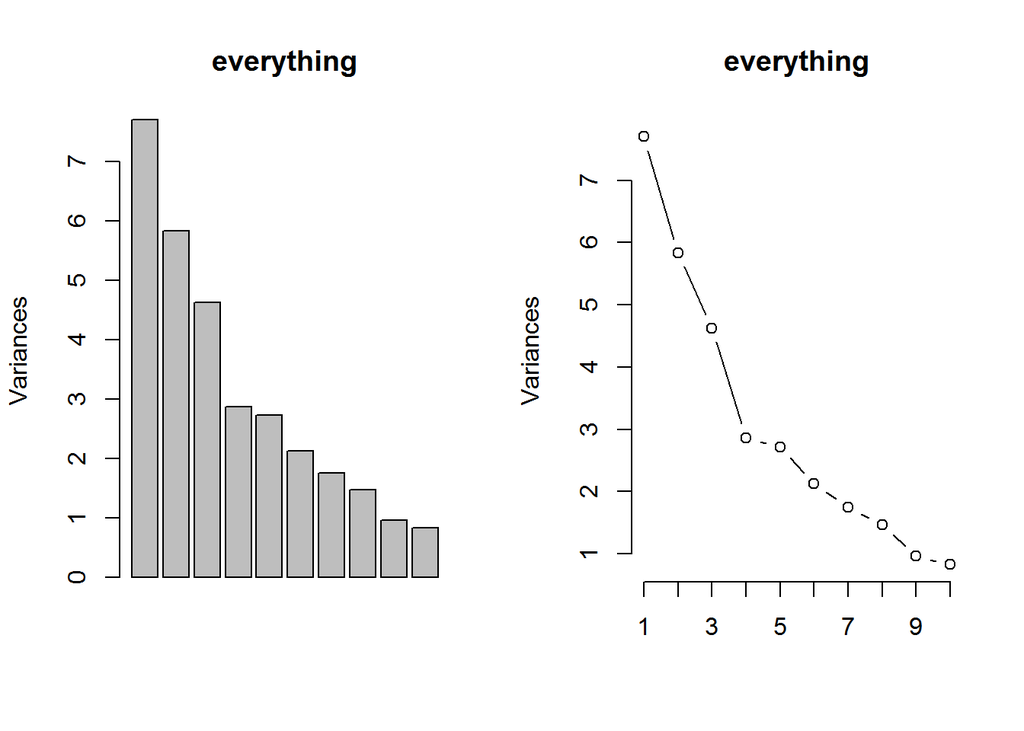

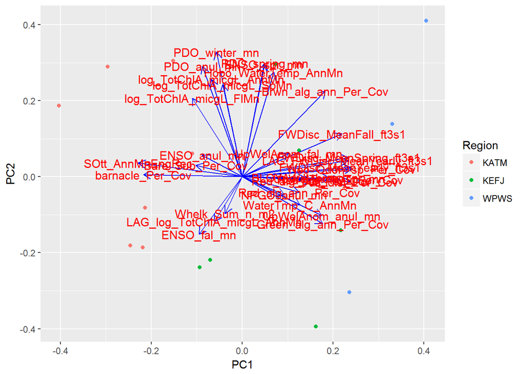

##### Scenario 1 - Region

NOTE:  
chose to retain Spring Freshwater over LAG Annual Freshwater  
chose to retain PDO over ENSO  
chose to retain log Chla spring over PDO Winter  
chose to retain Freshwater Yearly over Neo-Odon algae  
chose to retain Upwelling Annual over Water Temp (buoys)  
chose to retain Fucus over BLOY Adults, Upwelling spring, Red algae perennial, and Red algae TOTAL  
Then had to reduce to 17 variables, since we have only 17 observations at the Region level.

##### Scenario 2 - Region

##### Scenario 3 - Region

##### Scenario 4 - Region

##### Scenario 5 - Region

##### Scenario 6 - Region

##### Scenario 7 - Region

##### Scenario 8 - Region

##### Scenario 9 - Region

##### Scenario 10 - Region

##### Scenario 11 - Region

##### Scenario 12 - Region

##### Scenario 13 - Region

##### Scenario 14 - Region

##### Scenario 15 - Region

##### Scenario 16 - Region

##### Scenario 17 - Region

##### AIC values for all Regional models

```
##     Model        AIC
## 1   Sce_4 -42.250807
## 2  Sce_11 -27.189837
## 3   Sce_1  -8.063201
## 4   Sce_3  -7.330222
## 5  Sce_17  -5.999331
## 6   Sce_8  -3.619279
## 7   Sce_2  -2.667597
## 8  Sce_15   5.043078
## 9  Sce_16   7.039943
## 10  Sce_9  17.811782
## 11 Sce_13  18.220283
## 12 Sce_12  19.332962
## 13 Sce_10  19.932915
## 14  Sce_7  22.402045
## 15 Sce_14  23.140452
## 16  Sce_5  25.586733
## 17  Sce_6  25.616772
```

##### Coefficients for model(s) with lowest AIC scores

```
##
## Call:
## glm(formula = mussel_Anom ~ ., family = gaussian, data = BN_reg_sub_df)
##
## Deviance Residuals:
##         1          2          3          4          5          6
## -0.011458   0.017121  -0.017631   0.033480  -0.028880  -0.007644
##         7          8          9         10         11         12
##  0.009384  -0.014288   0.021616   0.021407  -0.037159  -0.009105
##        13         14         15         16         17
##  0.001735   0.043250   0.057698  -0.025575  -0.053948
##
## Coefficients:
##                          Estimate Std. Error t value Pr(>|t|)
## (Intercept)              0.674279   0.514566   1.310  0.28136
## log_TotChlA_micgL_AnnMn  0.585141   0.111815   5.233  0.01358 *
## FWDisc_MeanYearly_ft3s1  0.045352   0.007061   6.423  0.00765 **
## ENSO_anul_mn            -0.274059   0.052309  -5.239  0.01353 *
## NPGO_anul_mn            -0.073817   0.052785  -1.398  0.25643
## UpWelAnom_anul_mn       -0.026043   0.003219  -8.089  0.00395 **
## Hobo_WaterTemp_AnnMn    -0.208477   0.023969  -8.698  0.00320 **
## Bare_Sub_Per_Cov         0.010559   0.012090   0.873  0.44674
## Whelk_Sum_n_m2          -0.002969   0.002585  -1.148  0.33404
## SOtt_AnnMnEngRec        -0.015802   0.018342  -0.862  0.45231
## barnacle_Per_Cov         0.007455   0.004630   1.610  0.20577
## Fuc_dist_Per_Cov         0.014268   0.005876   2.428  0.09348 .
## Brwn_alg_ann_Per_Cov    -0.027166   0.008636  -3.146  0.05144 .
## Green_alg_ann_Per_Cov   -0.016807   0.004887  -3.439  0.04126 *
## ---
## Signif. codes:  0 '***' 0.001 '**' 0.01 '*' 0.05 '.' 0.1 ' ' 1
##
## (Dispersion parameter for gaussian family taken to be 0.004732397)
##
##     Null deviance: 2.902831  on 16  degrees of freedom
## Residual deviance: 0.014197  on  3  degrees of freedom
## AIC: -42.251
##
## Number of Fisher Scoring iterations: 2
```

##### NOTE: If other scales come up with other “best” models, test it all all scale levels.

##### Also, test scenario 13 at other scales.

##### Test model performance of the “best” model at each level on all levels.

##### Test all scenarios from Region data at lower scales.

##### Scenario WINNER of the Site-level analysis

```
## [1] 3.583126
```

##### Scenario WINNER from the Transect-level analysis

```
## [1] -3.868123
```

##### Scenario 4 - Region best model

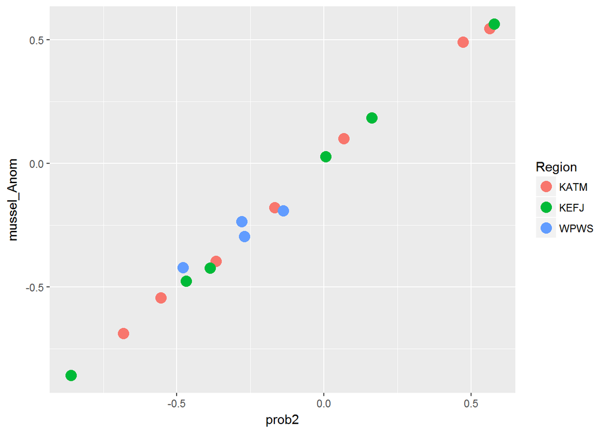

```
##      mussel_Anom
## [1,]   0.9975516
```

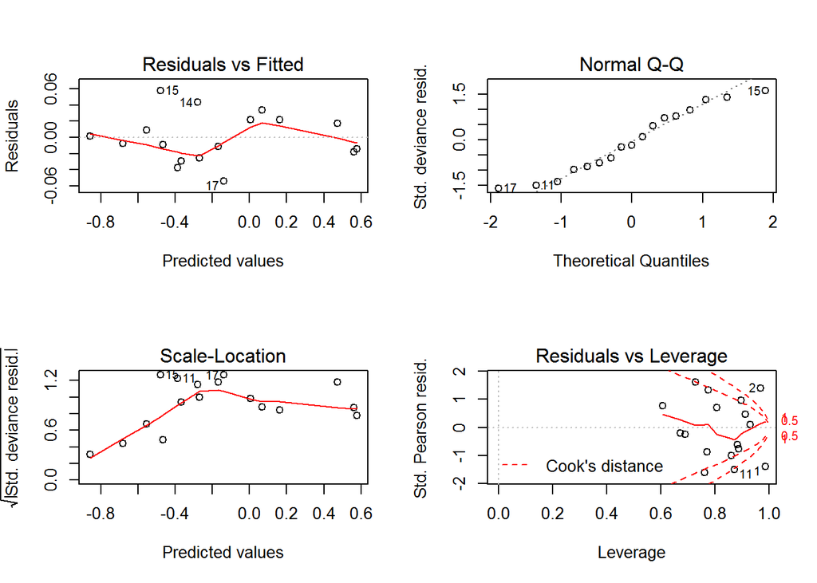

##### Scenario 11

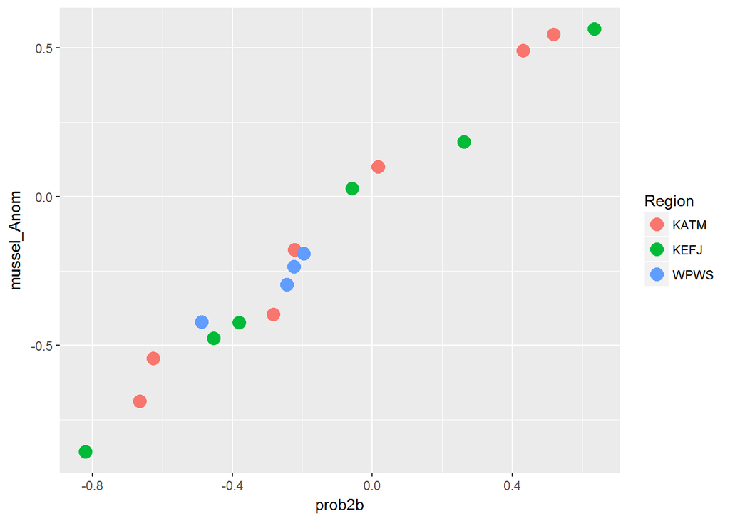

```
##      mussel_Anom
## [1,]   0.9892622
```

##### Scenario 1

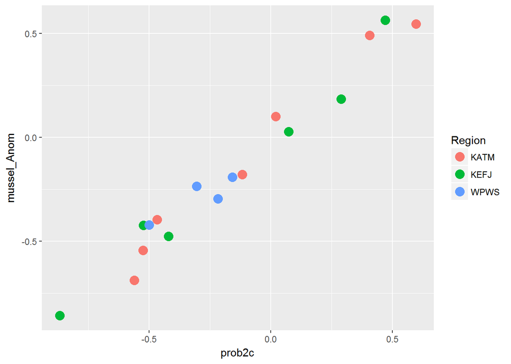

```
##      mussel_Anom
## [1,]   0.9836239
```

##### Site winner

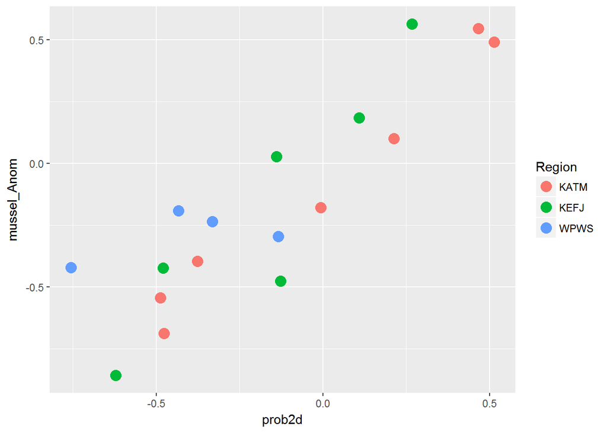

```
##      mussel_Anom
## [1,]   0.8893864
```

##### Transect winner

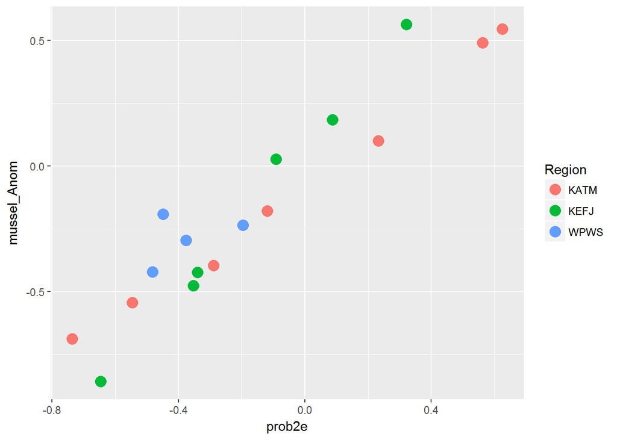

```
##      mussel_Anom
## [1,]   0.9514561
```

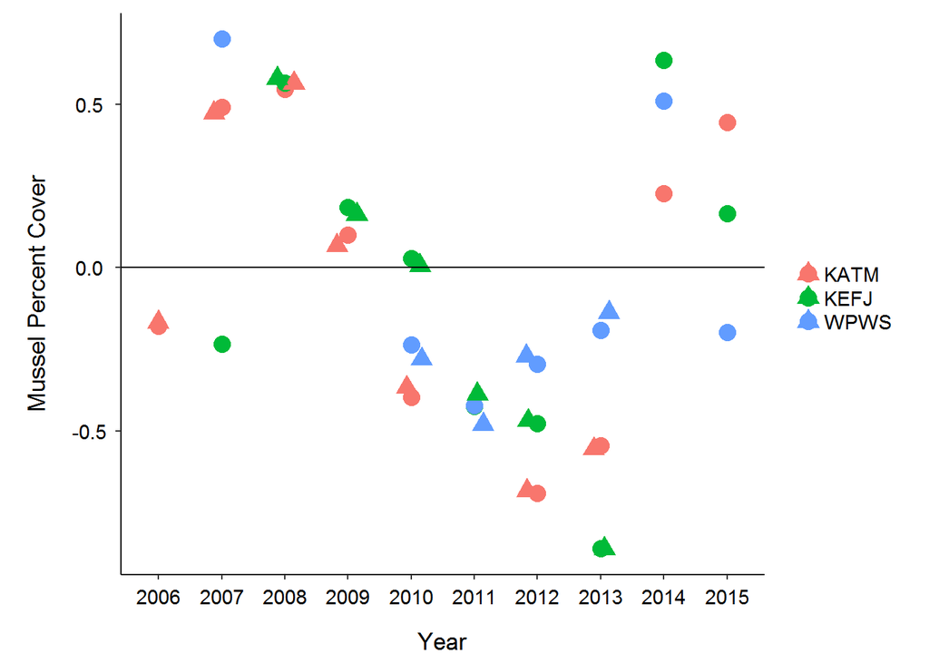

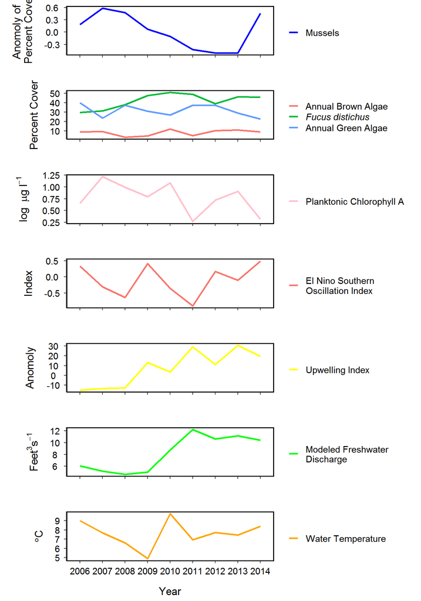

## Site-level Analysis

```
## Importance of components:
##                           PC1    PC2    PC3     PC4     PC5     PC6
## Standard deviation     2.4326 2.3555 1.9987 1.72857 1.56065 1.41809
## Proportion of Variance 0.1793 0.1681 0.1211 0.09054 0.07381 0.06094
## Cumulative Proportion  0.1793 0.3475 0.4685 0.55906 0.63286 0.69380
##                            PC7     PC8     PC9   PC10    PC11   PC12
## Standard deviation     1.34953 1.21544 1.17473 1.0655 0.98443 0.8768
## Proportion of Variance 0.05519 0.04477 0.04182 0.0344 0.02937 0.0233
## Cumulative Proportion  0.74899 0.79376 0.83558 0.8700 0.89935 0.9226
##                           PC13    PC14    PC15   PC16    PC17    PC18
## Standard deviation     0.78482 0.68975 0.60441 0.5233 0.49164 0.46059
## Proportion of Variance 0.01866 0.01442 0.01107 0.0083 0.00732 0.00643
## Cumulative Proportion  0.94131 0.95572 0.96679 0.9751 0.98242 0.98885
##                           PC19    PC20    PC21    PC22    PC23    PC24
## Standard deviation     0.33346 0.30367 0.26417 0.22011 0.15256 0.13393
## Proportion of Variance 0.00337 0.00279 0.00211 0.00147 0.00071 0.00054
## Cumulative Proportion  0.99221 0.99501 0.99712 0.99859 0.99930 0.99984
##                           PC25    PC26      PC27      PC28  PC29     PC30
## Standard deviation     0.06460 0.03278 1.169e-15 3.407e-16 3e-16 2.46e-16
## Proportion of Variance 0.00013 0.00003 0.000e+00 0.000e+00 0e+00 0.00e+00
## Cumulative Proportion  0.99997 1.00000 1.000e+00 1.000e+00 1e+00 1.00e+00
##                             PC31      PC32      PC33
## Standard deviation     2.382e-16 2.036e-16 1.722e-16
## Proportion of Variance 0.000e+00 0.000e+00 0.000e+00
## Cumulative Proportion  1.000e+00 1.000e+00 1.000e+00
```

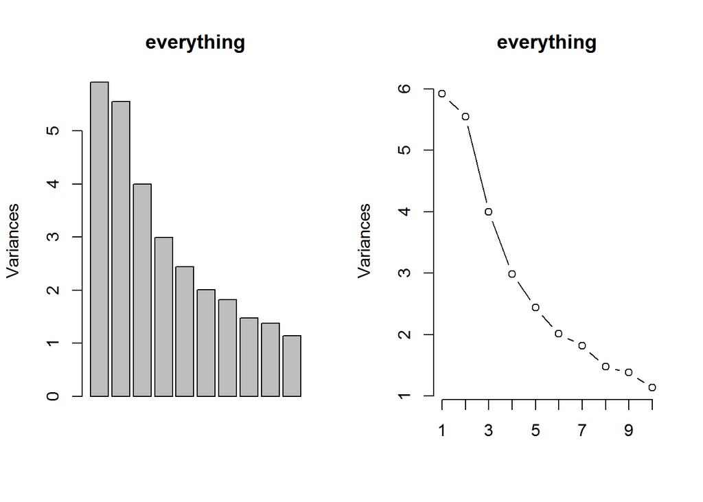

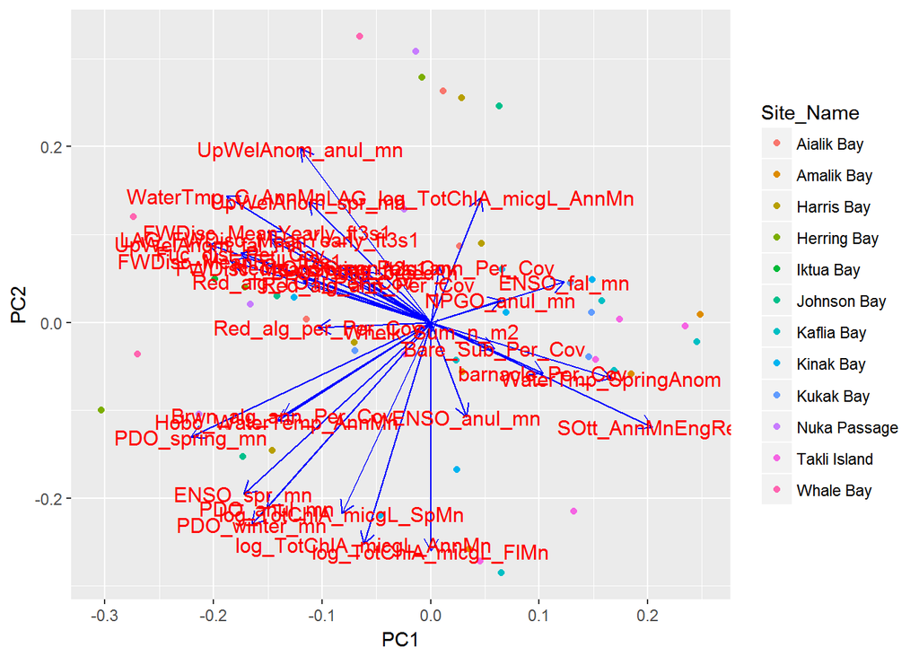

##### Scenario 1 - Site

*NOTE:  
chose Sea Otter eng rec over barnacles and bare substrate  
chose NPGO annual over ENSO fall  
chose Water temp buoys over Neo-Odon algae and Red annual algae  
chose Freshwater Yearly over LAG Freshwater Yearly  
chose Fucus over Red algae TOTAL and Upwelling fall and Freshwater Fall  
chose HOBO Water temp over Brown algae  
chose PDO annual over PDO Winter  
Also removed ENSO Spring, ENSO Annual, PDO Annual and PDO Spring due to singularities

##### Scenario 2 - Site

##### Scenario 3 - Site

##### Scenario 4 - Site

##### Scenario 5 - Site

##### Scenario 6 - Site

##### Scenario 7 - Site

##### Scenario 8 - Site

##### Scenario 9 - Site

##### Scenario 10 - Site

##### Scenario 11 - Site

##### Scenario 12 - Site

##### Scenario 13

##### Scenario 14 - Site

##### Scenario 15 - Site

##### Scenario 16 - Site

##### Scenario 17 - Site

##### Scenario 18 - Site

##### Scenario 19 - Site

##### Scenario 20 - Site

##### Scenario 21 - Site

##### Scenario 22 - Site

##### Scenario 23 - Site

##### Scenario 24 - Site

##### Scenario 25 - Site

##### Scenario 26 - Site

##### Scenario 27 - Site

##### Scenario 28 - Site

##### AIC values for all Site models

```
##       Model      AIC
## 1  Sce_28_s 71.84565
## 2  Sce_27_s 75.69550
## 3  Sce_24_s 75.88648
## 4  Sce_18_s 77.83488
## 5  Sce_26_s 79.30016
## 6  Sce_25_s 79.53424
## 7  Sce_15_s 80.17677
## 8  Sce_13_s 80.92781
## 9  Sce_14_s 81.19983
## 10 Sce_17_s 81.83946
## 11 Sce_22_s 81.89060
## 12 Sce_16_s 82.10818
## 13  Sce_7_s 82.12386
## 14  Sce_8_s 82.15145
## 15 Sce_23_s 82.17674
## 16 Sce_12_s 82.33071
## 17 Sce_11_s 82.40448
## 18 Sce_21_s 82.47318
## 19  Sce_9_s 83.81996
## 20 Sce_19_s 84.21813
## 21 Sce_10_s 86.58349
## 22  Sce_2_s 90.31254
## 23  Sce_6_s 93.21779
## 24  Sce_5_s 93.31026
## 25 Sce_20_s 93.77724
## 26  Sce_3_s 95.30850
## 27  Sce_1_s 95.67174
## 28  Sce_4_s 97.50154
```

##### Coefficients for model(s) with lowest AIC scores

```
##
## Call:
## glm(formula = mussel_Anom ~ ., family = gaussian, data = BN_reg_sub_df)
##
## Deviance Residuals:
##      Min        1Q    Median        3Q       Max
## -0.96008  -0.31516   0.06693   0.40606   0.96437
##
## Coefficients:
##                         Estimate Std. Error t value Pr(>|t|)
## (Intercept)             -3.49332    0.92487  -3.777 0.000493 ***
## log_TotChlA_micgL_AnnMn  0.74706    0.30031   2.488 0.016913 *
## WaterTmp_C_AnnMn         0.24357    0.09192   2.650 0.011303 *
## SOtt_AnnMnEngRec         0.15546    0.03605   4.312 9.59e-05 ***
## Brwn_alg_ann_Per_Cov    -0.02810    0.01413  -1.988 0.053363 .
## ---
## Signif. codes:  0 '***' 0.001 '**' 0.01 '*' 0.05 '.' 0.1 ' ' 1
##
## (Dispersion parameter for gaussian family taken to be 0.2340812)
##
##     Null deviance: 17.7483  on 46  degrees of freedom
## Residual deviance:  9.8314  on 42  degrees of freedom
## AIC: 71.846
##
## Number of Fisher Scoring iterations: 2
```

##### Scenario WINNER from Region-level analysis

```
## [1] 79.35655
```

##### Scenario WINNER from the Transect-level analysis

```
## [1] 67.49646
```

##### Scenario 28 - Site best model

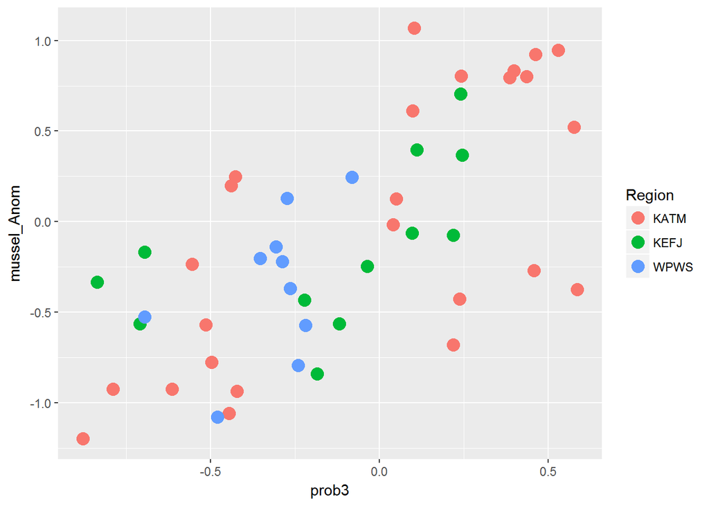

```
##      mussel_Anom
## [1,]   0.6678819
```

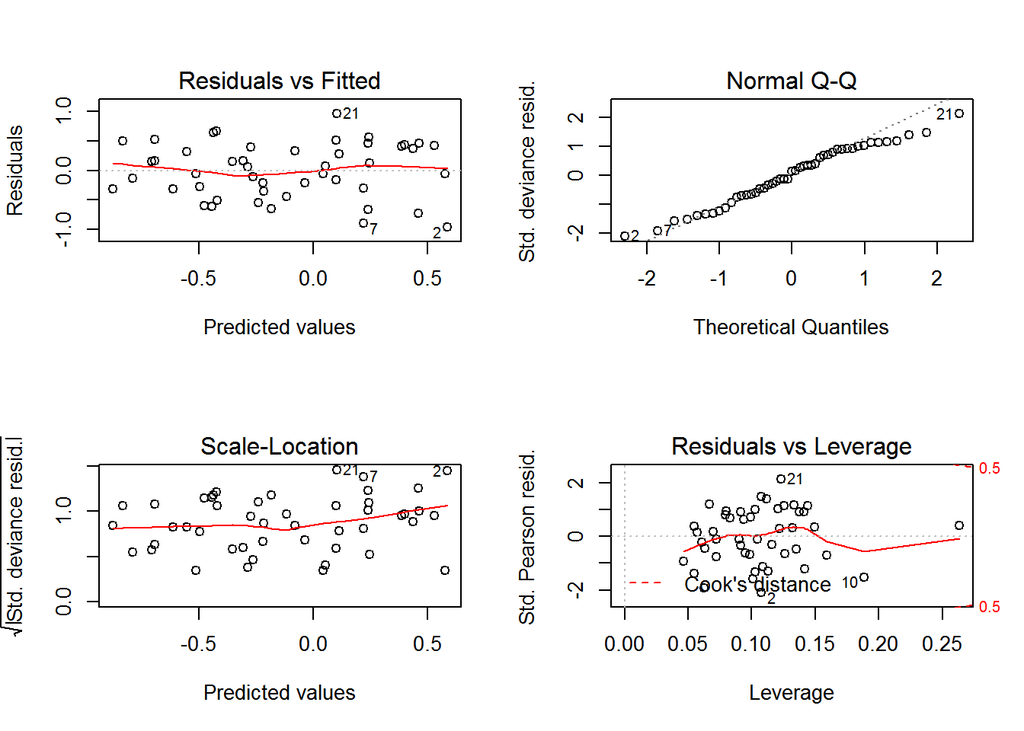

##### Region Winner

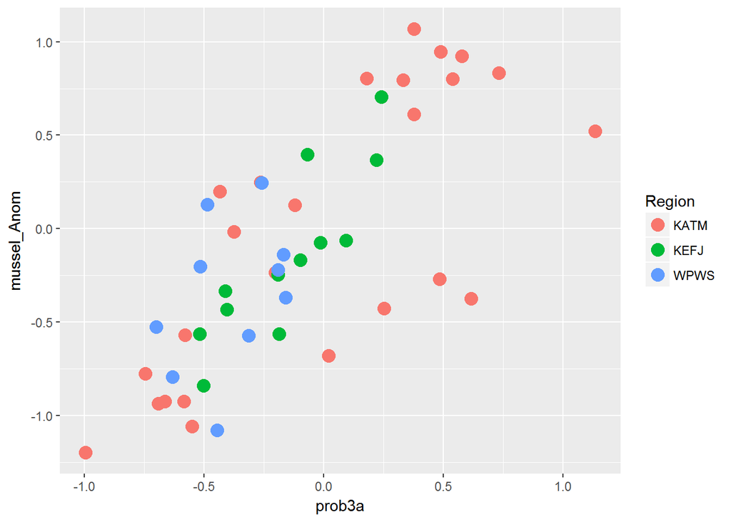

```
##      mussel_Anom
## [1,]   0.7462344
```

##### Transect Winner

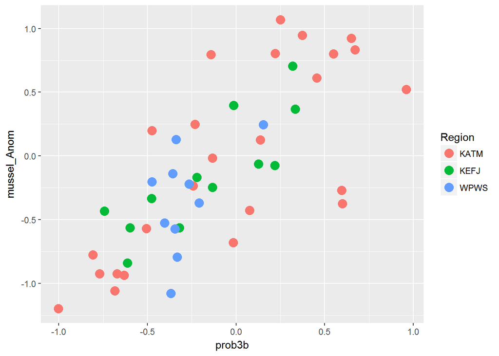

```
##      mussel_Anom
## [1,]   0.7453487
```

##### Scenario 27

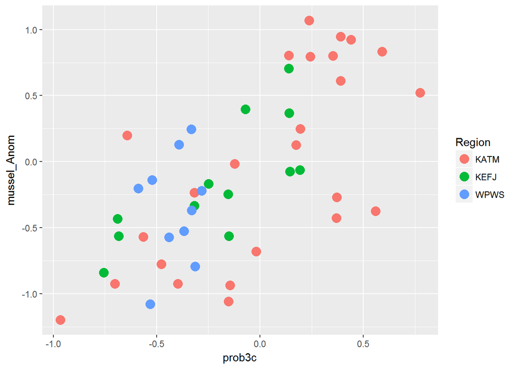

```
##      mussel_Anom
## [1,]   0.6692033
```

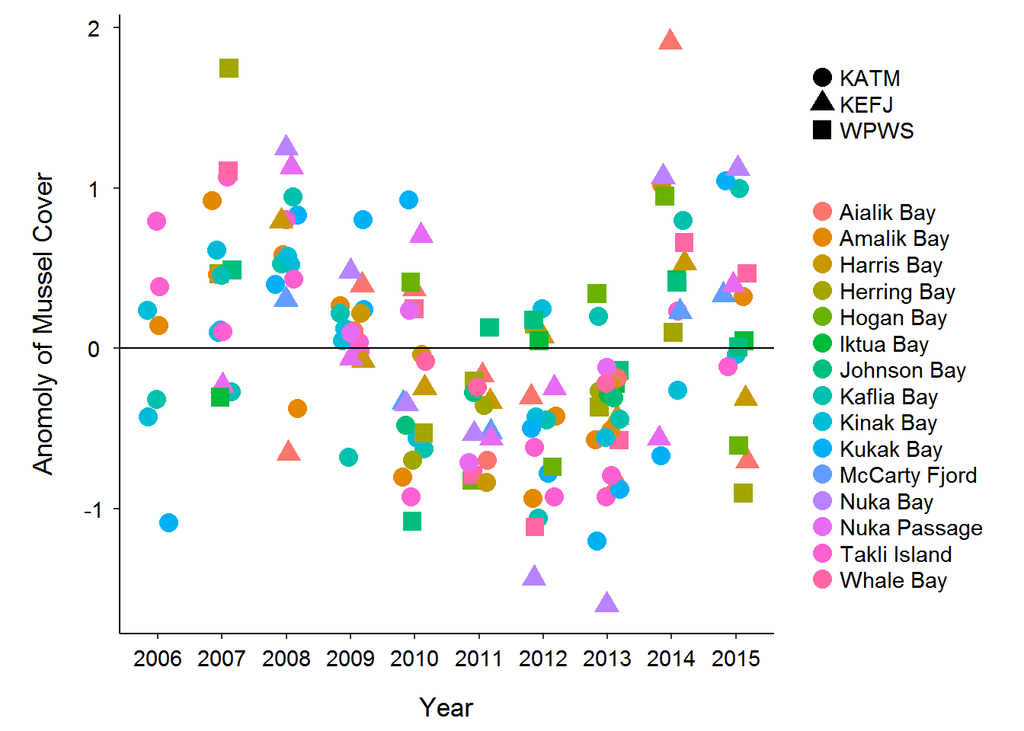

## Transect-level Analyses (Within-Site)

```
## Importance of components:
##                           PC1    PC2   PC3     PC4     PC5     PC6     PC7
## Standard deviation     2.3243 2.2666 1.880 1.75237 1.51768 1.40138 1.28093
## Proportion of Variance 0.1589 0.1511 0.104 0.09032 0.06775 0.05776 0.04826
## Cumulative Proportion  0.1589 0.3100 0.414 0.50430 0.57204 0.62980 0.67806
##                            PC8     PC9    PC10    PC11    PC12    PC13
## Standard deviation     1.17652 1.16452 1.09472 1.00543 0.94818 0.92039
## Proportion of Variance 0.04071 0.03989 0.03525 0.02973 0.02644 0.02492
## Cumulative Proportion  0.71877 0.75866 0.79391 0.82364 0.85008 0.87500
##                          PC14    PC15    PC16    PC17    PC18    PC19
## Standard deviation     0.8668 0.82128 0.80497 0.75685 0.69455 0.57301
## Proportion of Variance 0.0221 0.01984 0.01906 0.01685 0.01419 0.00966
## Cumulative Proportion  0.8971 0.91693 0.93599 0.95284 0.96703 0.97669
##                           PC20    PC21    PC22    PC23    PC24    PC25
## Standard deviation     0.56059 0.42225 0.34843 0.30241 0.25208 0.14636
## Proportion of Variance 0.00924 0.00524 0.00357 0.00269 0.00187 0.00063
## Cumulative Proportion  0.98593 0.99117 0.99474 0.99743 0.99930 0.99993
##                           PC26      PC27      PC28      PC29      PC30
## Standard deviation     0.04792 1.119e-14 6.301e-15 4.905e-15 4.007e-15
## Proportion of Variance 0.00007 0.000e+00 0.000e+00 0.000e+00 0.000e+00
## Cumulative Proportion  1.00000 1.000e+00 1.000e+00 1.000e+00 1.000e+00
##                             PC31      PC32      PC33      PC34
## Standard deviation     3.353e-15 3.338e-15 4.985e-16 2.289e-16
## Proportion of Variance 0.000e+00 0.000e+00 0.000e+00 0.000e+00
## Cumulative Proportion  1.000e+00 1.000e+00 1.000e+00 1.000e+00
```

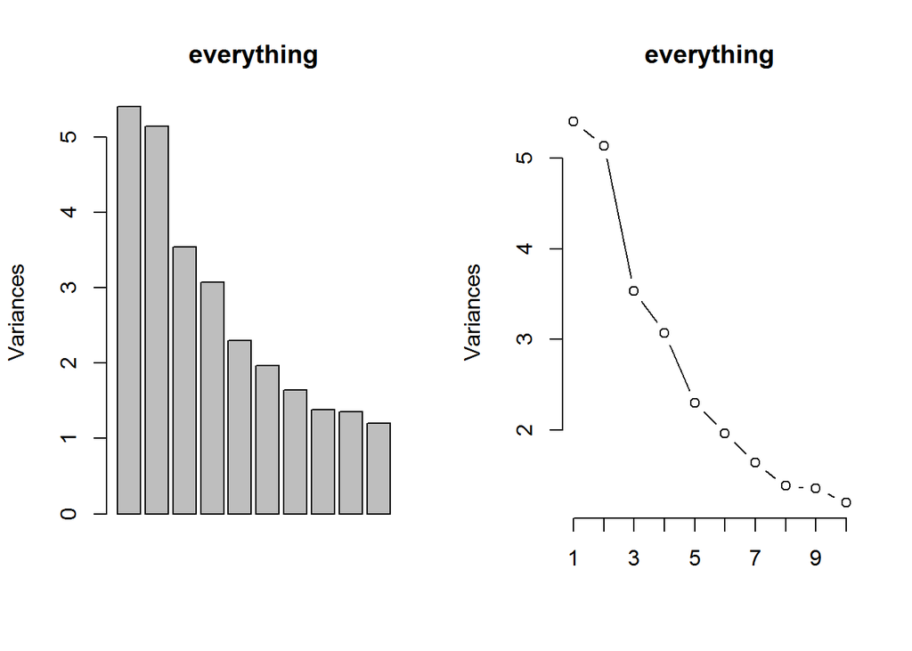

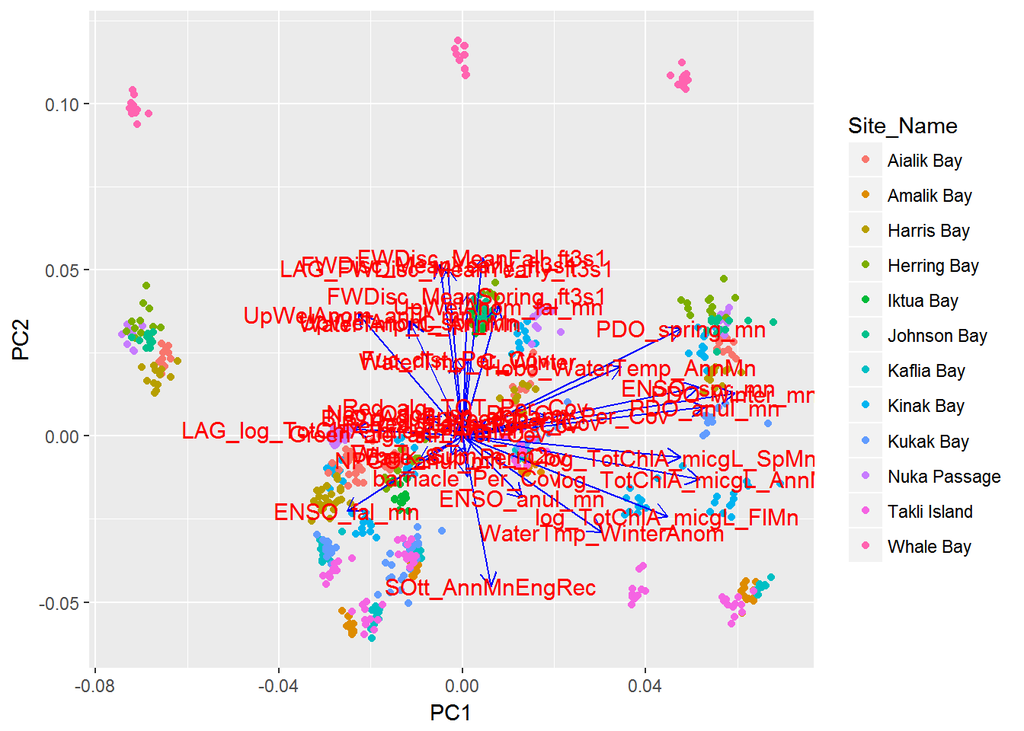

##### Scenario 1 - Transect PCA-informed model

*NOTE:  
chose NPGO annual over ENSO fall  
chose Green algae over LAG annual Chla  
chose Bare Substrate over Barnacles and Sea Otter eng rec  
chose PDO Annual over PDO Winter  
chose Brown algae over ENSO Spring  
chose HOBO Water Temp over PDO Spring  
chose Water Temp Annual Buoys over Upwelling Spring and Neo-Odon algae  
chose Freshwater Yearly over Fucus and LAG Freshwater Yearly  
chose Water Temp Winter over Freshwater Spring and Red algae TOTAL  
Also removed Upwelling Fall and Upwelling Winter Anomaly due to singularities

##### Scenario 2 - Transect

##### Scenario 3 - Transect

##### Scenario 4 - Transect

##### Scenario 5 - Transect

##### Scenario 6 - Transect

##### Scenario 7 - Transect

##### Scenario 8 - Transect

##### Scenario 9 - Transect

##### Scenario 10 - Transect

##### Scenario 11 - Transect

##### Scenario 12 - Transect

##### Scenario 13 - Transect

##### Scenario 14 - Transect

##### Scenario 15 - Transect

##### Scenario 16 - Transect

##### Scenario 17 - Transect

##### Scenario 18 - Transect

##### Scenario 19 - Transect

##### Scenario 20 - Transect

##### Scenario 21 - Transect

##### Scenario 22 - Transect

##### Scenario 23 - Transect

##### Scenario 24 - Transect

##### Scenario 25 - Transect

##### Scenario 26 - Transect

##### Scenario 27 - Transect

##### Scenario 28 - Transect

##### Scenario 29 - Transect

```
##       Model      AIC
## 1  Sce_22_t 1894.785
## 2   Sce_4_t 1906.363
## 3  Sce_25_t 1909.536
## 4  Sce_24_t 1911.617
## 5   Sce_2_t 1912.064
## 6  Sce_23_t 1913.050
## 7   Sce_3_t 1914.627
## 8  Sce_21_t 1915.102
## 9   Sce_1_t 1915.375
## 10 Sce_19_t 1928.582
## 11 Sce_20_t 1928.722
## 12 Sce_29_t 1930.670
## 13 Sce_14_t 1932.327
## 14 Sce_16_t 1935.349
## 15 Sce_18_t 1939.148
## 16 Sce_10_t 1939.583
## 17 Sce_13_t 1943.470
## 18  Sce_9_t 1954.246
## 19 Sce_28_t 1961.932
## 20 Sce_27_t 1962.033
## 21 Sce_26_t 1963.111
## 22 Sce_12_t 1963.636
## 23  Sce_5_t 1966.002
## 24 Sce_17_t 1966.002
## 25  Sce_7_t 1966.490
## 26 Sce_11_t 1968.511
## 27 Sce_15_t 1970.527
## 28  Sce_6_t 1991.004
## 29  Sce_8_t 1992.993
```

##### Coefficients for model(s) with lowest AIC scores

```
##
## Call:
## glm(formula = mussel_Anom ~ ., family = gaussian, data = BN_reg_sub_df)
##
## Deviance Residuals:
##      Min        1Q    Median        3Q       Max
## -2.75951  -0.75829  -0.00292   0.73898   3.06782
##
## Coefficients:
##                        Estimate Std. Error t value Pr(>|t|)
## (Intercept)            0.966532   0.197848   4.885 1.30e-06 ***
## UpWelAnom_fal_mn       0.007773   0.002285   3.401 0.000711 ***
## UpWelAnom_anul_mn     -0.028077   0.003029  -9.269  < 2e-16 ***
## Hobo_WaterTemp_AnnMn  -0.064289   0.024489  -2.625 0.008862 **
## Bare_Sub_Per_Cov      -0.007725   0.002375  -3.253 0.001203 **
## Red_alg_TOT_Per_Cov    0.001950   0.001201   1.624 0.104928
## Brwn_alg_ann_Per_Cov  -0.020686   0.004148  -4.988 7.85e-07 ***
## Green_alg_ann_Per_Cov -0.003052   0.001658  -1.841 0.066133 .
## ---
## Signif. codes:  0 '***' 0.001 '**' 0.01 '*' 0.05 '.' 0.1 ' ' 1
##
## (Dispersion parameter for gaussian family taken to be 1.018094)
##
##     Null deviance: 805.11  on 659  degrees of freedom
## Residual deviance: 663.80  on 652  degrees of freedom
## AIC: 1894.8
##
## Number of Fisher Scoring iterations: 2
```

##### Scenario Winner from Region-level analysis above

```
## [1] 1906.746
```

##### Scenario Winner from Site-level analysis above

```
## [1] 1910.221
```

##### Scenario 22 - Best Model

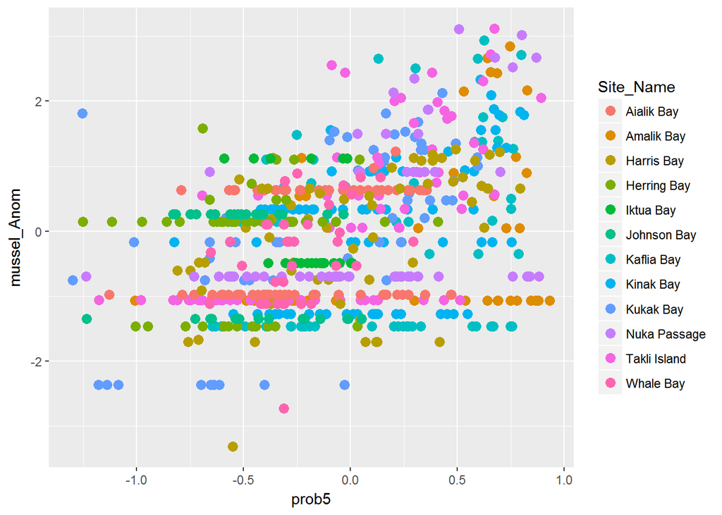

```
##      mussel_Anom
## [1,]   0.4189486
```

##### Region winning scenario

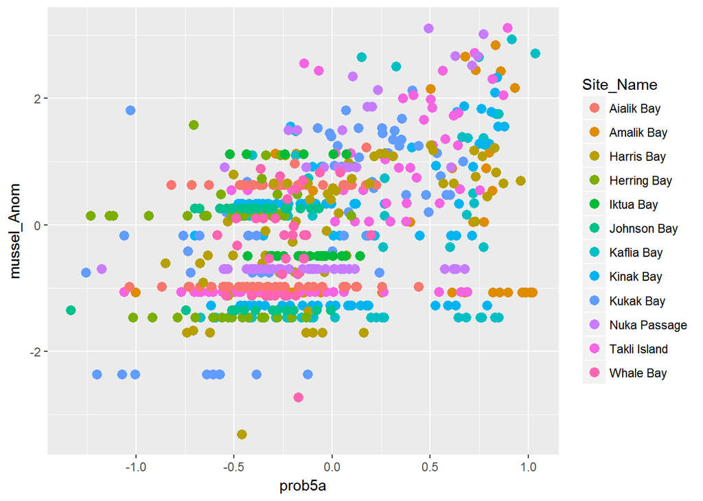

```
##      mussel_Anom
## [1,]   0.4190068
```

##### Site winning scenario

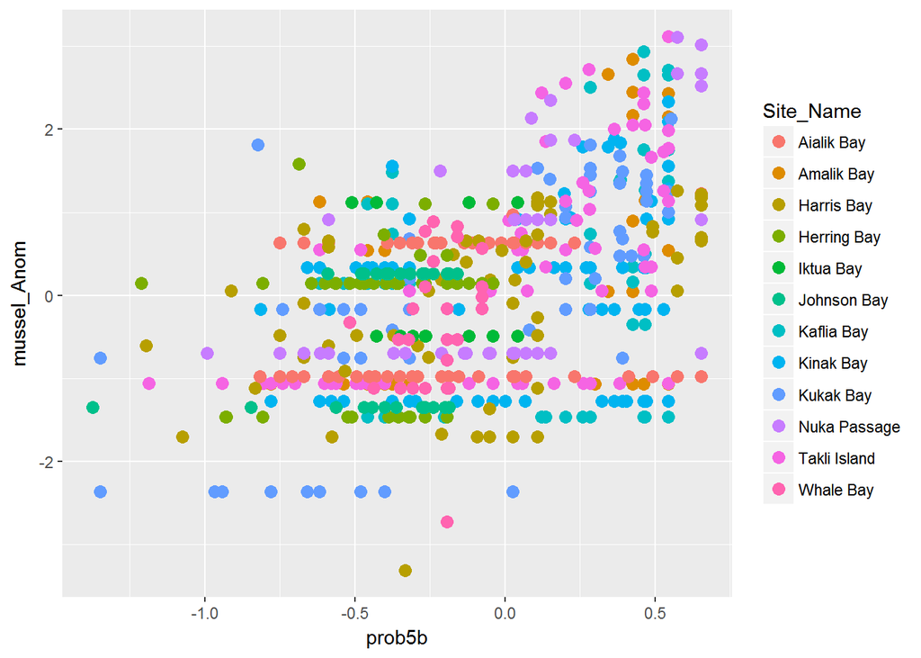

```
##      mussel_Anom
## [1,]   0.3850979
```

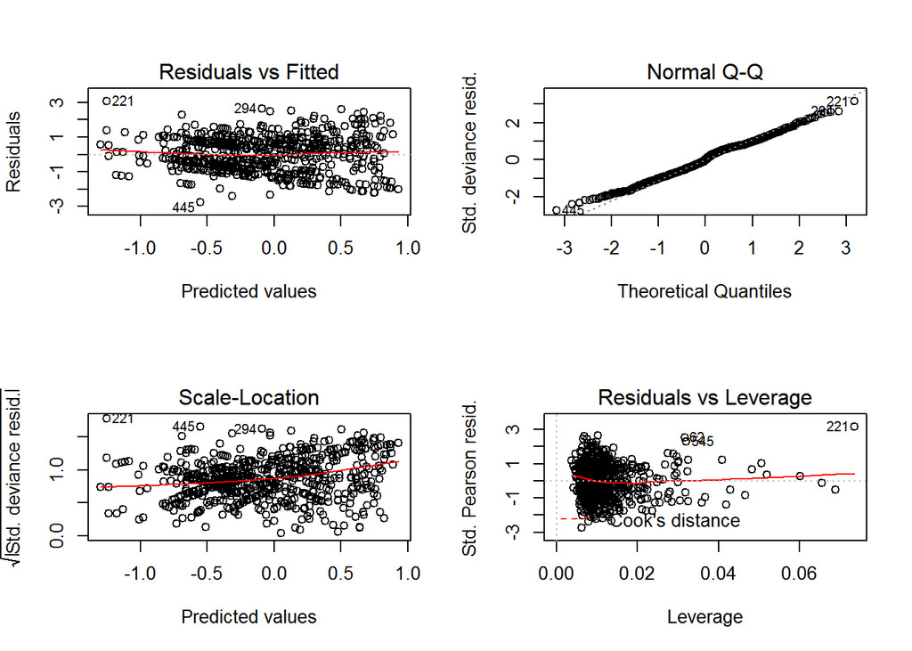

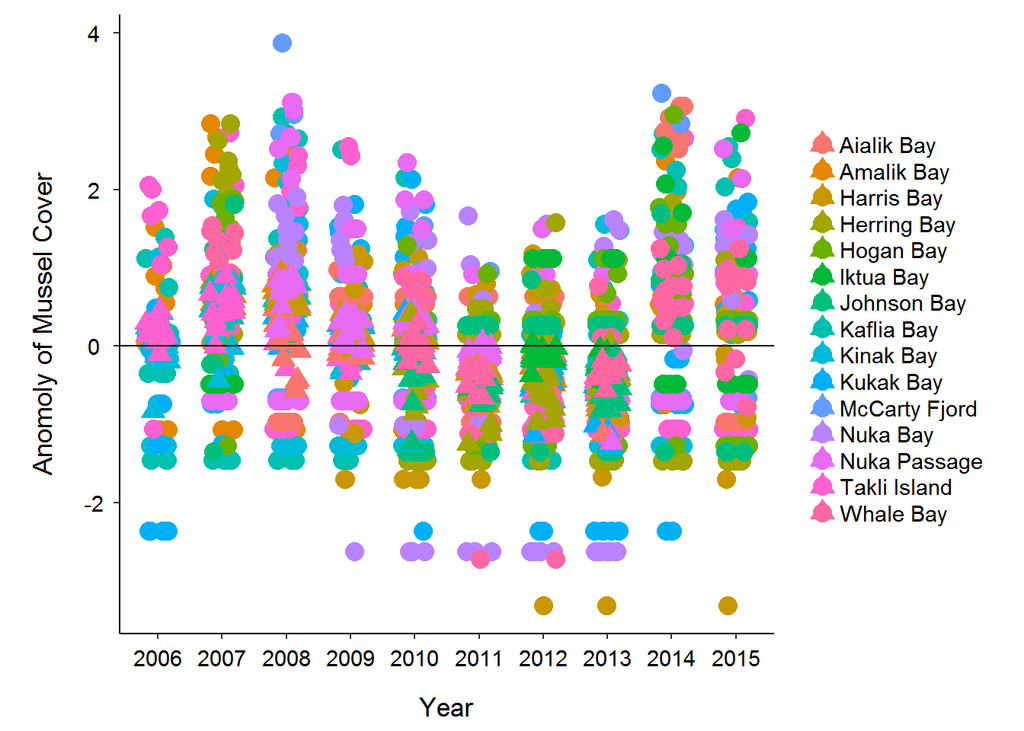